# Spatial statistical modeling with inlabru

Kyriacos Nicolaou (kyriakosn24@gmail.com)

October 10, 2024

# Quantifying Spatial Phenotype of puncta

## Load Libraries

We begin by loading the necessary libraries for spatial data handling, modeling, and visualization:

- [**sf**](https://r-spatial.github.io/sf/index.html): For handling spatial vector data (simple features).
- **INLA** and [**inlabru**](https://inlabru-org.github.io/inlabru/): For Bayesian inference using Integrated Nested Laplace Approximation.
- [**fmesher**](https://github.com/inlabru-org/fmesher): For creating spatial meshes, essential for continuous spatial models.
- [**ggplot2**](https://ggplot2.tidyverse.org/): For creating high-quality visualizations.
- [**terra**](https://rspatial.org/pkg/): For handling raster data efficiently.

The function `bru_safe_sp(force = TRUE)` ensures compatibility with spatial objects when using **inlabru**.

```r
library(INLA)
library(inlabru)
```

```r
library(sf)
library(fmesher)
library(ggplot2)
library(terra)
bru_safe_sp(force = TRUE)
```

## Read the Data

We read the spatial data components essential for our analysis:

Point Patterns: Locations of peroxisomes (`peroxisomes.geojson`). Boundaries: Cell boundaries defining the spatial domain (`domain.geojson`). Mesh Boxes: Used for creating spatial meshes (`meshbox.geojson`). Covariate Images: Environmental covariates loaded as raster data.

```r
path_to_data <- "../data/processed/inlabru_compatible/stitched_cells1-6/"

peroxisomes <- st_read(paste0(path_to_data, "peroxisomes.geojson"),crs = NA)
domain <- st_read(paste0(path_to_data, "domain.geojson"),crs = NA)
boxes <- st_read(paste0(path_to_data, "meshbox.geojson"),crs = NA)
mitochondria <- rast(paste0(path_to_data,"raw/mitochondria.tif"))
er <- rast(paste0(path_to_data,"raw/er.tif"))
fractional_distance <- rast(paste0(path_to_data,"distance/fractional distance.tif"))
proximity_mitochondria <- rast(paste0(path_to_data,"proximity/mitochondria.tif"))

crs(mitochondria) <- NA
crs(fractional_distance) <- NA
crs(er) <- NA
crs(proximity_mitochondria) <- NA
```

## Inspect the Imported Dataset

Before moving on, we inspect the dataset to confirm that all data components were loaded successfully and that they align spatially as expected. In this visualization, we will:

- **Mesh Boxes**: Displayed as outlines to provide spatial context for the analysis domain.
- **Cell Boundaries**: Displayed in red the domain where we do the spatial analysis (cytosole).
- **Peroxisomes**: Displayed as points in dark green to indicate their locations within the cell.

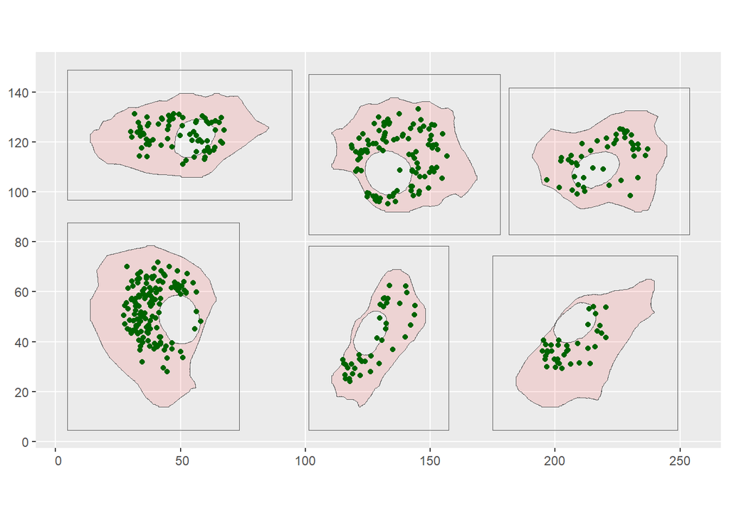

```r
# Inspect the dataset visually to verify successful import and alignment
ggplot() +
  gg(boxes, alpha = 0) +
  gg(domain, fill = "red", alpha = 0.1) +
  gg(peroxisomes, color = "darkgreen")
```

## Standardize the continuous covariates

For the continuous covariate maps it is good practice to standardize them, such that the distribution of their pixel’s values has a mean equal to zero and standard deviation equal to 1. This helps stabilize the inference process and makes the results more easy to interpret

```r
standardize <- function(raster_data, polygons) {

  masked_raster <- mask(raster_data, polygons)

  values_within_polygons <- values(masked_raster, na.rm = TRUE)

  mean_val <- mean(values_within_polygons)
  sd_val <- sd(values_within_polygons)

  cells_in_polygons <- !is.na(values(masked_raster))

  all_values <- values(raster_data)

  all_values[cells_in_polygons] <- (all_values[cells_in_polygons] - mean_val)/sd_val

  all_values[!cells_in_polygons] <- 0

  standardized_raster <- raster_data
  values(standardized_raster) <- all_values

  return(standardized_raster)
}

# standardize the continuous covariates
mitochondria = standardize(mitochondria,domain)
er = standardize(er,domain)
fractional_distance = standardize(fractional_distance,domain)
```

## Choose Cells for the Analysis

The data-set consists of 6 cells. Here, we will decide which cells to include for our model. Although we could filter out specific cells, for this analysis, we will include **all six cells** available in the data-set. The following code block filters the domains, boxes, and peroxisomes for a chosen list of cells. Moreover it makes sure to keep peroxisomes detected in the domains of interest

Note: Filtering is **not necessary for the covariate raster objects**, as they inlabru will sample them based on their spatial locations automatically. As long as the raster objects are properly aligned with the spatial data, they will provide the required information for the specified regions.

```r
# Choose which cells to include in the analysis
cell_indx <- c(1,2,3,4,5,6)

# filter the boundaries and meshboxes for the selected cells
domain <- domain[cell_indx, ]
boxes <- boxes[cell_indx, ]

# Filter puncta to include only those that are within the chosen boundaries
inside.indx <- apply(st_intersects(peroxisomes, domain, sparse = FALSE),1, function(x) any(x))
peroxisomes <- peroxisomes[inside.indx, ]
```

## Mesh Construction

An essential step in spatial analysis with **INLA** is the construction of a **spatial mesh** for the domain. Additionally, we build an **external mesh** to minimize artificial boundary effects on the random field. The construction of the mesh, requires an a list that includes the inner domain of interest and the boundary where the external mesh is bounded, moreover here we chose the maximum length of the edges in the mesh. The maximum edge length for the internal mesh triangles is set to **1 micrometer (μm)**. This value matches the spatial resolution of our covariate data, ensuring that important spatial features are represented accurately. For the external mesh, the maximum edge length is **4 μm** which helps avoiding artificial boundary effects while not increasing the computational cost by a lot. last there is a cutoff value for the minimum length of the mesh, which we set at **0.2 μm** to avoid the creation of overly small triangles, which can lead to numerical instability during the analysis.

In the code below, we create the mesh using the `fm_mesh_2d_inla()` function, specifying the boundary and external mesh boxes.

```r
mesh <- fm_mesh_2d_inla(boundary = list(domain,boxes), max.edge = c(1, 4),cutoff = 0.2)
```

We plot the mesh and the peroxisomes to verify that the mesh accurately represents the spatial domain and that all objects (points, boundaries) are well-aligned within the mesh.

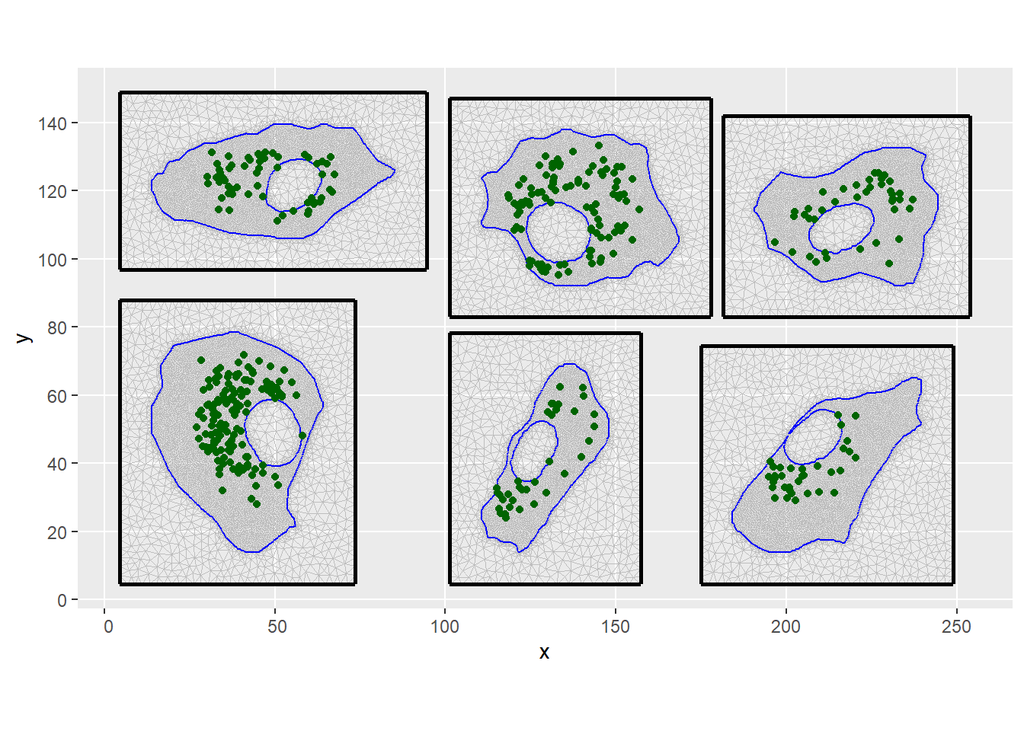

```r
ggplot() +
  gg(mesh) +
  gg(peroxisomes,color = "darkgreen")
```

## Modeling the spatial distribution of puncta

To quantify the **spatial phenotype of peroxisomes**, we consider a model for the **mean density** of points. The model aims to explain how the peroxisomes are distributed in relation to various covariates such as other imaged components and hidden spatial variation which models hidden processes and structures. We model the presence of puncta with a log gaussian cox process with covariates. In particular the log of the mean density is a linear combination that involves the covariates and a zero-mean gaussian random field.

Our model reads **mean density**:

where, $P_{\cdot}(\mathbf{r})$ are covariate maps and $\beta_{\cdot})$ coefficients for the following covariate maps - **`MT`**: Mitochondria - **`ER`**: Endoplasmic Reticulum (ER) - **`FD`**: Fractional Distance (relative distance between nucleus and cell boundary) - **`MP`**: Proximity to mitochondria, a binary map of the pixels that are at most $1\mu m$ away from a binary image of the mitochondria

- **Structured Random Effect**: `GF` represents the Gaussian Random Field with a mean of zero and a correlation structure. $Sigma$ which is of the Matern type, with a **smoothness parameter** of `α = 2`.2

## Priors:

- **Fixed Effects**: We use a **non-informative prior**, which is the default in `inlabru`. This is a normal distribution with a mean of zero and a precision of `0.001`.
- **GRF Priors** (PC-prior):
  - **Standard Deviation (`σ`)**: We set `P(σ > 2) = 0.01`, implying a weak prior belief that the standard deviation should not exceed `2`.
  - **Correlation Length (`ρ`)**: We set `P(ρ < 1) = 0.01`, suggesting that the correlation length should be larger than **1 μm**.

These priors are reasonable and weakly informative, given that we have no strong prior knowledge about the model parameters.

```r
matern <- inla.spde2.pcmatern(mesh, prior.sigma = c(2, 0.01), prior.range = c(1, 0.01))
```

## Model Construction

We now construct the model by including all relevant components in a formula. This model integrates the random field, covariate information, and a global intercept term:

Below is the code used to define the model:

```r
model<- geometry ~
  random.field(geometry, model = matern) +
  mitochondria +
  er +
  fractional_distance +
  proximity_mitochondria +
  Intercept(1)
```

Next, we fit the **Log-Gaussian Cox Process (LGCP)** model using `inlabru`. This model allows us to analyze the spatial point pattern of peroxisomes by incorporating covariates, a random field, and an intercept. The LGCP framework is particularly useful for modeling count data or point patterns over continuous space, making it ideal for our spatial phenotype analysis.

The inputs for fitting the model include:

- **Point Pattern (`peroxisomes`)**: Represents the locations of the peroxisomes, which is the target of our spatial modeling.
- **Spatial Domain (`boundary`)**: Specifies the spatial domain where the sampling takes place. This domain represents the boundaries of the cells.
- **Mesh (`mesh`)**: Represents the discretized version of the spatial domain, allowing us to compute the Gaussian Random Field (GRF) efficiently.

```r
fit <- lgcp(model, peroxisomes ,samplers = domain , domain = list(geometry = mesh))
```

## Results

we can view a summary of the results of fitting

```r
summary(fit)
```

```
## inlabru version: 2.12.0
## INLA version: 24.06.04
## Components:
## random.field: main = spde(geometry), group = exchangeable(1L), replicate = iid(1L), NULL
## mitochondria: main = linear(mitochondria), group = exchangeable(1L), replicate = iid(1L), NULL
## er: main = linear(er), group = exchangeable(1L), replicate = iid(1L), NULL
## fractional_distance: main = linear(fractional_distance), group = exchangeable(1L), replicate = iid(1L), NULL
## proximity_mitochondria: main = linear(proximity_mitochondria), group = exchangeable(1L), replicate = iid(1L), NULL
## Intercept: main = linear(1), group = exchangeable(1L), replicate = iid(1L), NULL
## Likelihoods:
##   Family: 'cp'
##     Tag: ''
##     Data class: 'sf', 'data.frame'
##     Response class: 'numeric'
##     Predictor: geometry ~ .
##     Used components: effects[random.field, mitochondria, er, fractional_distance, proximity_mitochondria, Intercept], latent[]
## Time used:
##     Pre = 0.967, Running = 353, Post = 7.17, Total = 361
## Fixed effects:
##                          mean    sd 0.025quant 0.5quant 0.975quant   mode kld
## mitochondria            0.029 0.050     -0.068    0.029      0.127  0.029   0
## er                      0.142 0.059      0.026    0.142      0.258  0.142   0
## fractional_distance     0.691 0.104      0.487    0.691      0.895  0.691   0
## proximity_mitochondria  0.431 0.126      0.184    0.431      0.678  0.431   0
## Intercept              -4.213 0.204     -4.651   -4.201     -3.847 -4.171   0
##
## Random effects:
##   Name     Model
##     random.field SPDE2 model
##
## Model hyperparameters:
##                          mean    sd 0.025quant 0.5quant 0.975quant   mode
## Range for random.field 16.870 3.493     11.203   16.466      24.89 15.611
## Stdev for random.field  0.897 0.119      0.685    0.889       1.15  0.874
##
## Deviance Information Criterion (DIC) ...............: -4826.38
## Deviance Information Criterion (DIC, saturated) ....: -4857.27
## Effective number of parameters .....................: -5707.51
##
## Watanabe-Akaike information criterion (WAIC) ...: 958.94
## Effective number of parameters .................: 5.61
##
## Marginal log-Likelihood:  -3453.19
##  is computed
## Posterior summaries for the linear predictor and the fitted values are computed
## (Posterior marginals needs also 'control.compute=list(return.marginals.predictor=TRUE)')
```

and plot the marginal posterior distributions of the parameters of the model

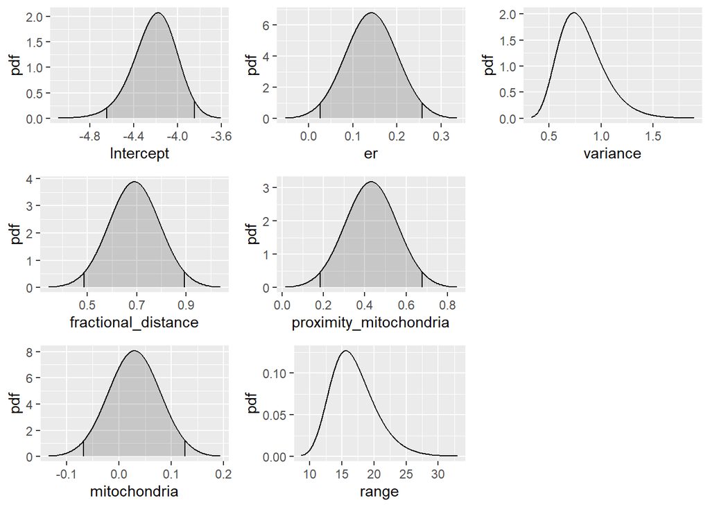

```r
multiplot(plot(fit, "Intercept"),
          plot(fit, "fractional_distance"),
          plot(fit, "mitochondria"),
          plot(fit, "er"),
          plot(fit, "proximity_mitochondria"),
          plot(spde.posterior(fit, "random.field", what = "range")),
          plot(spde.posterior(fit, "random.field", what = "variance")),
          cols = 3
          )
```

we save the posterior marginals

```r
library(jsonlite)

# sacing the results in a json format

posterior_marginals <- list (
  mitochondria =  list(pdf = fit$marginals.fixed$mitochondria, summary = fit$summary.fixed["mitochondria",]),
  er           = list(pdf = fit$marginals.fixed$er,summary = fit$summary.fixed["er",]),
  intercept    = list(pdf = fit$marginals.fixed$Intercept,summary = fit$summary.fixed["Intercept",]),
  `mitochondria proximity` = list(pdf = fit$marginals.fixed$proximity_mitochondria,summary = fit$summary.fixed["proximity_mitochondria",]),
  `proximity fraction` = list(pdf = fit$marginals.fixed$fractional_distance,summary = fit$summary.fixed["fractional_distance",]),
  range = list(pdf = fit$marginals.hyperpar$`Range for random.field`,summary = fit$summary.hyperpar["Range for random.field",]),
  `standard deviation` = list(pdf = fit$marginals.hyperpar$`Stdev for random.field`,summary = fit$summary.hyperpar["Stdev for random.field",])
)


json_data <- toJSON(posterior_marginals, pretty = TRUE, auto_unbox = TRUE)

# Write the JSON data to a file
write(json_data, file =  "../data/output/marginals.json")
```

next we will get the predicted GRF and the mean density by sampling from the posterior distribution

```r
# make mesh for prediction

cell3 = domain[3,]



# Filter puncta to include only those that are within cell4
inside.indx <- apply(st_intersects(peroxisomes, cell3, sparse = FALSE),1, function(x) any(x))
peroxisomes_cell3 <- peroxisomes[inside.indx, ]
```

```r
# create the prediction mesh
pred.df <- fm_pixels(mesh, mask =cell3)
```

```r
# setup prediction formulas

formulas <- ~ list(
  rf = random.field ,
  lambda = exp( random.field + mitochondria + er + fractional_distance + proximity_mitochondria +
  Intercept))

prediction <- predict(fit, pred.df,  formulas,   n.samples = 8,num.threads = 8)
```

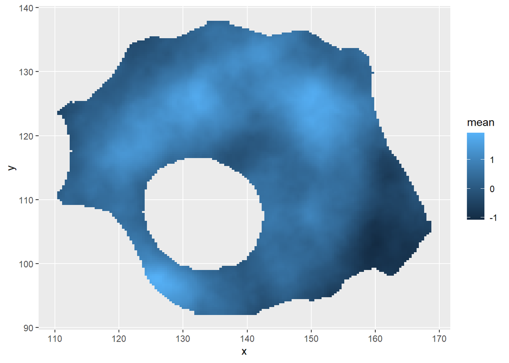

```r
grf.plot <- ggplot() +
    gg(prediction$rf,geom = "tile")
grf.plot
```

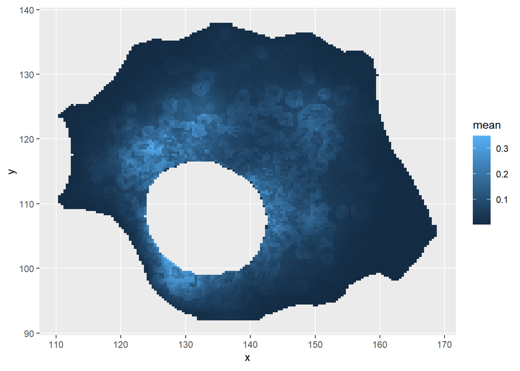

```r
mean_density.plot <- ggplot() +
    gg(prediction$lambda,geom = "tile")
mean_density.plot
```

Now we will calculate the Pearson residuals which are a meassure of how well the model captures the mean density. To do that we follow the steps in this vignette: [Residual Analysis of spatial point process models using Bayesian methods](https://inlabru-org.github.io/inlabru/articles/2d_lgcp_residuals_sf.html)

To do that we need to load some functions

```r
source(system.file(
  file.path("misc", "2d_lgcp_residuals_functions_sf.R"),
  package = "inlabru"))
```

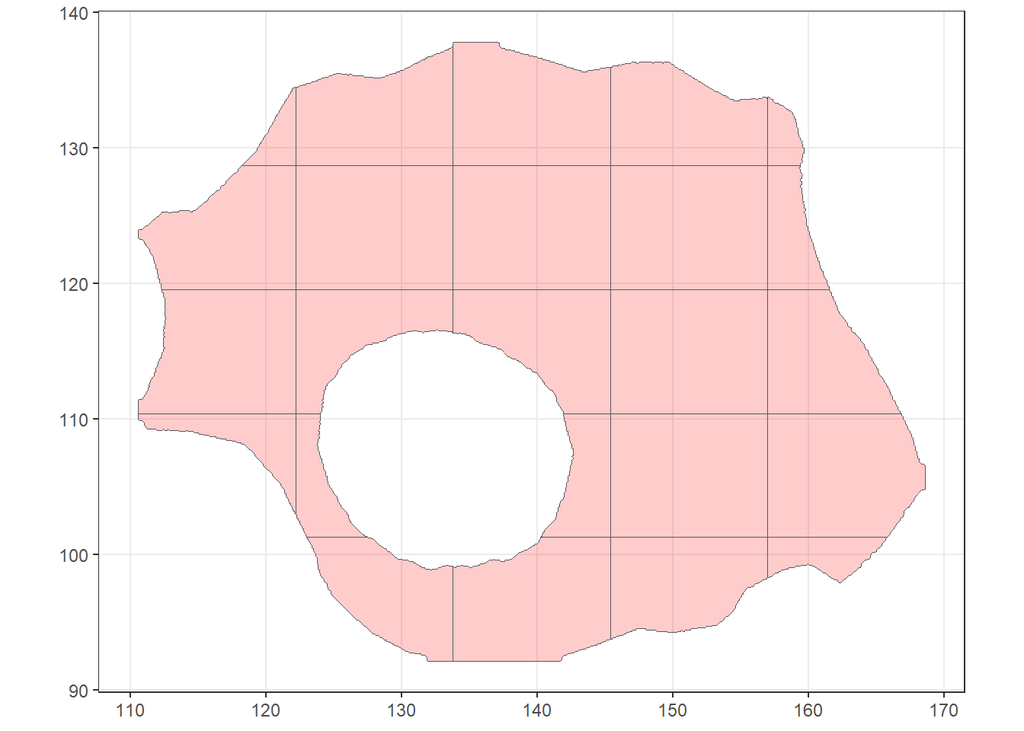

```r
# we partition the cell, in squares for the estimation of the residual
residual_mesh <- partition(samplers = cell3, nrows = 5, ncols = 5)

ggplot() +
  gg(residual_mesh,fill = "red",alpha = 0.2)
```

```r
residuals.prepare <- prepare_residual_calculations(
  samplers = residual_mesh, domain = mesh,
  observations = peroxisomes_cell3
)
```

```r
res <- predict(
    object = fit,
    newdata = residuals.prepare$df,
    ~ {
      lambda <- eval(expression( exp( random.field + mitochondria + er + fractional_distance + proximity_mitochondria +
  Intercept)))
      h3 <- 1 / sqrt(lambda)
      data.frame(
        Pearson_Residuals =
           as.vector(residuals.prepare$A_sum %*% h3[obs]) -
            as.vector(residuals.prepare$A_integrate %*% (h3 * lambda)[!obs])
      )
    },
    n.samples = 8,num.threads = 8)
```

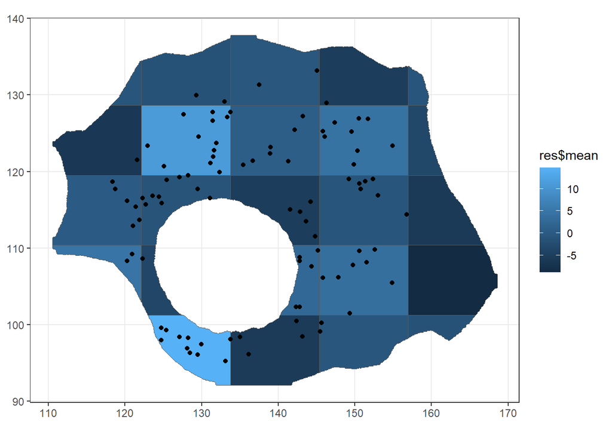

```r
ggplot() +
  gg(residual_mesh, aes(fill = res$mean), alpha = 1)+
  gg(peroxisomes_cell3)
```

Here we see that the residuals, are often beyond the range of (-2,2), which might be considered as a bad fit according to the pearson residuals. This is not unexpected as we fit the model on many cells as if they are realizations of a single process, in order to get the spatial phenotype of the population. However a model that considers cell to cell variation might capture individual cells better

## Make nicer figures of the predictions

In the rest of this notebook we will make the prediction figures nicer and save them

```r
plot.theme <- theme(
    panel.grid = element_blank(),
    axis.ticks = element_blank(),
    axis.text = element_blank(),
    axis.title = element_blank(),
    legend.position = "bottom",
    legend.direction = "horizontal",
    legend.box.margin = margin(t = -20, r = 0, b = 2, l = 0),
    legend.title = element_text(margin = margin(b = 5),size = 9),
    legend.text = element_text(size = 9)
  )

colorbar.guide = guide_colorbar(
      direction = "horizontal",          # Arrange the color bar horizontally
      title.position = "top",            # Position the title at the top of the color bar
      title.hjust = 0.5,                 # Center the title
      label.position = "bottom",         # Position the labels below the color bar
      barwidth = unit(5, "cm"),          # Adjust the width of the color bar
      barheight = unit(0.5, "cm")        # Adjust the height of the color bar
    )
```

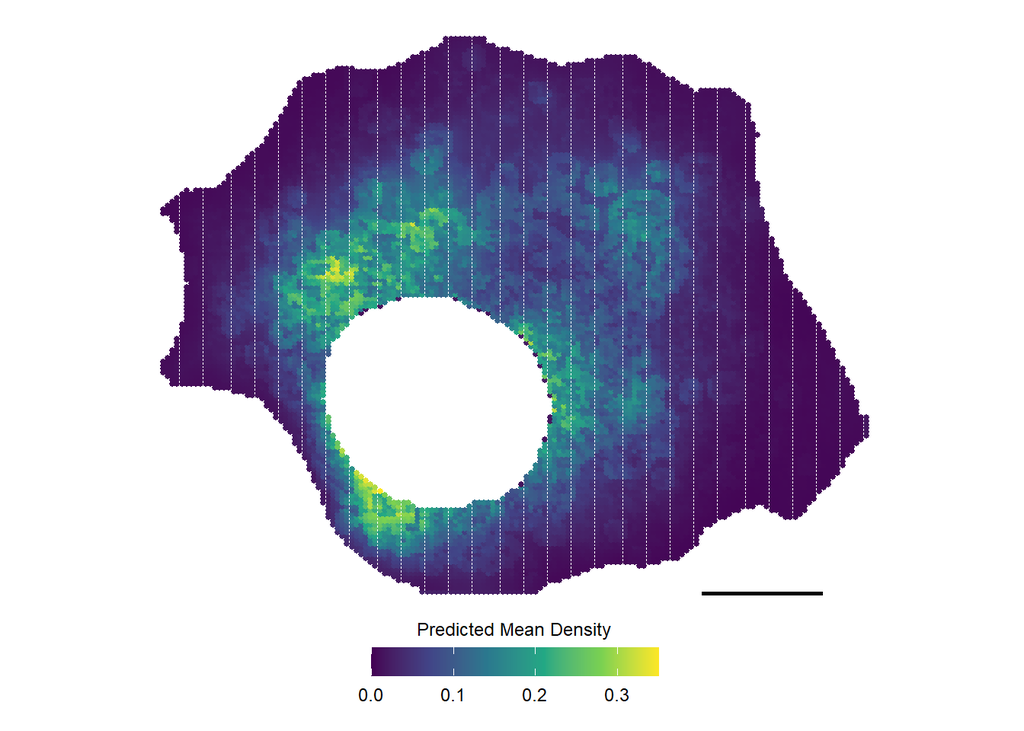

```r
mean_density.plot<- ggplot(prediction$lambda) +
  geom_sf(aes(color = mean), size = 1) +
    scale_color_viridis_c(
    option = "viridis",
    limits = c(0,max(prediction$lambda$mean)),
    name = "Predicted Mean Density",
    guide = colorbar.guide) +
  #         geom_sf(data = peroxisomes_cell3,color = "green")+
  theme_minimal() +
    plot.theme +
  annotate(
    "segment",
    x = 155, y = 92,
    xend = 155 + 10, yend = 92,
    color = "black", size = 1
  )
mean_density.plot
```

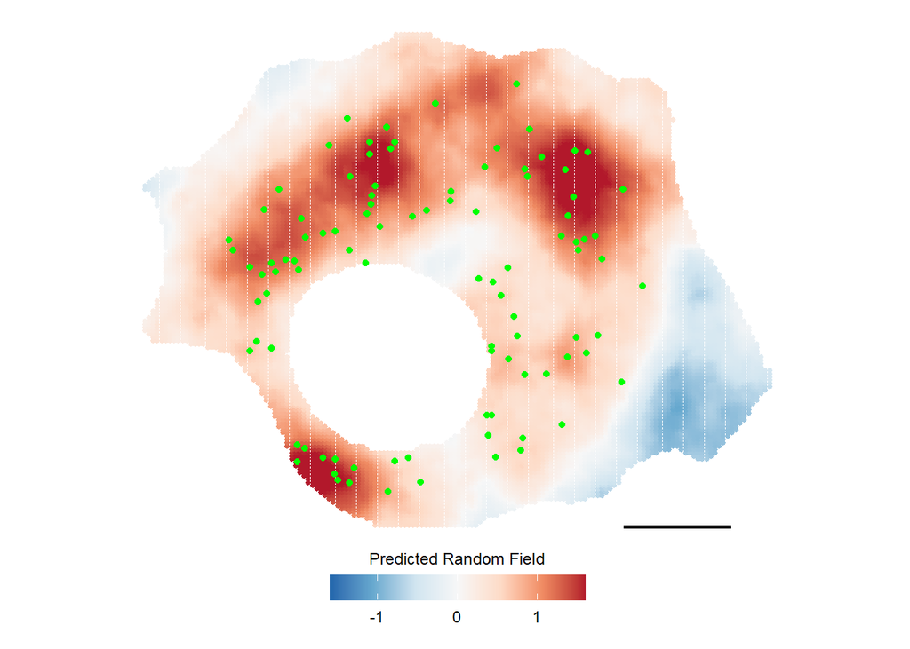

```r
grf.plot <- ggplot(prediction$rf) +
  geom_sf(aes(color = mean),size = 1) +
  geom_sf(data = peroxisomes_cell3,color = "green") +
  scale_color_distiller(
    palette = "RdBu",
    direction = -1,
    limits = c(-1.6, 1.6),
        oob = scales::squish,
    name = "Predicted Random Field",
    guide = colorbar.guide
  ) +
  theme_minimal() +
  plot.theme  +
    annotate(
    "segment",
    x = 155, y = 92,
    xend = 155 + 10, yend = 92,
    color = "black", size = 1)

grf.plot
```

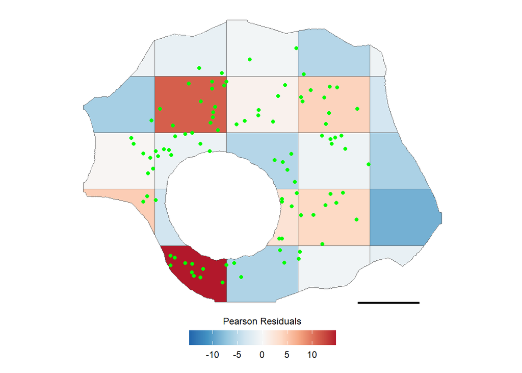

```r
# Calculate the limit for symmetric color scaling
limit <- max(c(abs(min(res$mean, na.rm = TRUE)), max(res$mean, na.rm = TRUE)))


residuals.plot <- ggplot() +
  geom_sf(data = residual_mesh, aes(fill = res$mean), alpha = 1) +
  geom_sf(data = peroxisomes_cell3,color = "green") +
   scale_fill_gradientn(
  colours = rev(brewer.pal(9, "RdBu")),
  name = "Pearson Residuals",
  limits = c(-limit, limit),
  guide =  colorbar.guide) +
  theme_minimal() +
  plot.theme +
    annotate(
    "segment",
    x = 155, y = 92,
    xend = 155 + 10, yend = 92,
    color = "black", size = 1
  )

residuals.plot
```

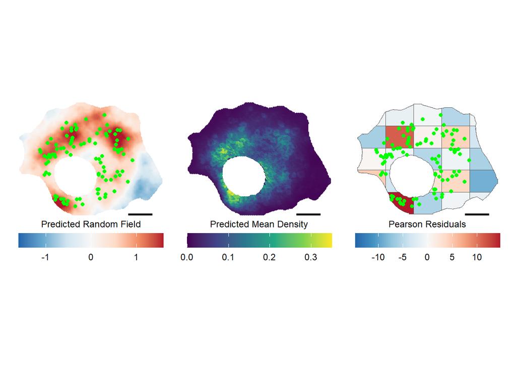

```r
combined_plot <- grf.plot + mean_density.plot + residuals.plot
combined_plot
```

```r
ggsave("../figures/peroxisomes_grf.svg",
       width = 6,height = 8,
      units = "cm",
      plot = grf.plot)

ggsave("../figures/peroxisomes_md.svg",
       width = 6,height = 8,
      units = "cm",
      plot = mean_density.plot)

ggsave("../figures/peroxisomes_res.svg",
       width = 6,height = 8,
      units = "cm",
      plot = residuals.plot)
```